Ranked SIMEX Corrected Student Growth Percentiles:

Why they are needed and preliminary implementation with Georgia Milestones data.

Adam R. VanIwaarden

National Center for the Improvement  
of Educational Assessment (NCIEA)

Qi Qin

*Georgia Department of Education (GA DOE)*

June 2017

# 1 The Measurement Error Problem and Corrections

Measurement error (ME) is an inherent component of all standardized tests, and the impact that ME can have when test score data are used to compute student growth and teacher/school evaluation measures has been the focus of a growing body of academic research. Specifically in the area of Student Growth Percentile (SGP) measures of student progress, ME has been found to create bias that can disadvantage students with lower prior achievement and vice versa. This bias is transferred to aggregate measures of educator effectiveness when a disproportionate number of students with relatively low/high prior achievement are concentrated in a classroom or school (Lockwood & Castellano, 2015; Shang, VanIwaarden, & Betebenner, 2015).

Researchers have proposed several useful methods for correcting the effects of ME. The use of Simulation/Extrapolation (SIMEX) techniques has been found to effectively eliminate the ME induced bias related to prior achievement in SGPs (Shang et al., 2015), and this method is a currently available for SGP calculation in the [`SGP` package](https://github.com/CenterForAssessment/SGP) (Betebenner, VanIwaarden, Domingue, & Shang, 2017) for the [`R` statistical program](http://www.r-project.org/). Currently several states utilize the SIMEX corrected measures in their student growth modeling and evaluation policies.

However, the SIMEX corrected SGPs also have technical limitations. At an individual level, the corrected SGPs have larger errors than the uncorrected, or “standard”, SGPs (McCaffrey, Castellano, & Lockwood, 2015; Shang et al., 2015). McCaffrey, et al. (2015) first suggested that ranking the SIMEX SGP values may present a possible alternative that would have the beneficial properties of both SGP estimate types. Castellano and McCaffrey (2017) recently investigated the properties of the percentile ranked SIMEX SGP (RS-SGP) at the aggregate level for MSGP estimates of educator effectiveness. They found that the majority of the error variance in standard MSGP values is due to “sampling variability” (i.e. a classroom is considered a sample of all possible students), but that a substantial amount was also due to bias caused by ME. SIMEX correction can remove much of this bias initially. By subsequently taking the percentile ranks of the SIMEX corrected values and then aggregating these percentile ranks, the excess variance from the SIMEX estimation is removed. Furthermore they found that, at the individual level, the distribution of the RS-SGPs is also more uniformly distributed (similar to the standard SGP) rather than the SIMEX SGPs typical U-shaped distribution. The uniform distribution of the individual SGP values is a desirable characteristic because it suggests that the full range of SGP growth values (1-99) is equally likely to be attained.

Given the potential promise of RS-SGP, it is now calculated along with the SIMEX values in the `SGP` package[^1]. Further insights from that implementation are discussed next.

# 2 SGP Package Implementation of Ranked SIMEX SGP

In their study, Castellano and McCaffrey report simply taking the percentile rank of the computed SIMEX SGP values to get the RS-SGP. However, unlike the SIMEX SGP values computed through data simulations in the `SGP` package, they compute their values using a closed-form equation. This produces continuous SIMEX SGP values, which allow for a more detailed ranking than using the integer values computed in the `SGP` package. Although their process helps to better understand the theoretical groundings of the various SGP estimates, it is only appropriate under particular assumptions about the data and ME structures that do not hold in the real-world situations.

Without a continuous value, the percentile ranking[^2] of a set of numbers that is already on a percentile scale does not produce results that differ substantially from the original in absolute value or distribution. Therefore a solution was required in the simulation process that would allow for a more continuous SIMEX SGP to be established. In following up with the authors they suggested that more granular SIMEX SGPs be established in the simulations, however this would require the already computationally and time intensive process to take 10 times longer. Furthermore, previously calculated SIMEX values would no longer be reproducible. A simpler solution was used that allows the estimated SIMEX values to be placed on a 1/8<sup>th</sup> interval by calculating arithmetic midpoints between each percentile’s predicted score values[^3]. This resulted in RS-SGP values that were more uniformly distributed in initial tests with real and simulated data.

Figure 1 shows the distribution of the three types of SGP estimates for 2016 8<sup>th</sup> Grade Mathematics SGP analyses in Georgia: uncorrected (“standard”), SIMEX corrected and Ranked SIMEX. Note that these results are from analyses that use up to three years of data (two prior and the current year), which the authors indicate will also greatly reduce ME bias.

**Figure 1:** Comparison of the Uniformity of Distributions for 8<sup>th</sup> Grade Mathematics Estimates.

[figure not shown]

By definition, the standard SGP is uniformly distributed *given any prior test score*, suggesting that any level of growth is equally likely regardless of prior achievement. This is a critical distinction, and Castellano and McCaffrey do not discuss the conditional uniformity of the RS-SGP. We find that this uniformity is not met in either the application of the closed-form equations to simulated data or in our initial tests with real data in the `SGP` package, although the RS-SGP distribution is much closer to uniform than that of the SIMEX SGPs.

The following figures are “Goodness of Fit” charts that are produced using the `SGP` package for each of the three SGP estimate types, and they can help investigate the SGP distribution in more detail. The “Student Growth Percentile Range” panel at bottom left shows the empirical distribution of SGPs given prior scale score deciles in the form of a 10 by 10 cell grid. Percentages of student growth percentiles between the 10<sup>th</sup>, 20<sup>th</sup>, 30<sup>th</sup>, 40<sup>th</sup>, 50<sup>th</sup>, 60<sup>th</sup>, 70<sup>th</sup>, 80<sup>th</sup>, and 90<sup>th</sup> percentiles were calculated based upon the empirical decile of the cohort’s prior year scaled score distribution. Perfect uniform distribution conditional on prior score would be indicated by a “10” in each cell. Deviations from perfect fit are indicated by red and blue shading. The further above 10 the darker the red, and the further below 10 the darker the blue. The bottom right panel of each plot is a [Q-Q plot](https://en.wikipedia.org/wiki/Q%E2%80%93Q_plot) which compares the observed distribution of SGPs with the theoretical (uniform) distribution. An ideal plot here will show black step function lines that do not deviate from the ideal, red line which traces the 45 degree angle of perfect fit (as is seen here in the first plot for the standard SGP).

These plots display typical distributions of each SGP variant from the same 2016 8<sup>th</sup> Grade Mathematics SGP analyses as depicted above. The Standard SGPs are nearly perfectly distributed conditional upon prior achievement. The SIMEX and, to a lesser extent, RS-SGP distributions are skewed towards higher percentiles at the lower levels of achievement and lower growth for the higher prior achievement deciles.

**Figure 2:** Goodness of Fit Plot for 2016 *Standard* 8<sup>th</sup> Grade Mathematics SGPs.

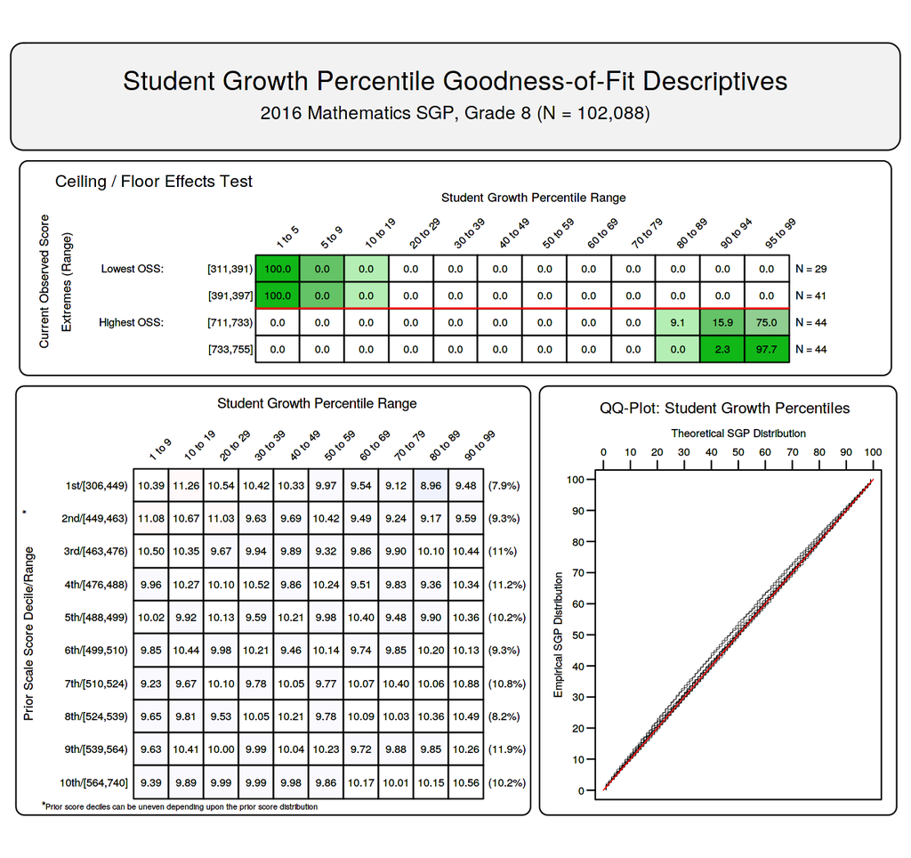

**Figure 3:** Goodness of Fit Plot for 2016 *SIMEX* 8<sup>th</sup> Grade Mathematics SGPs.

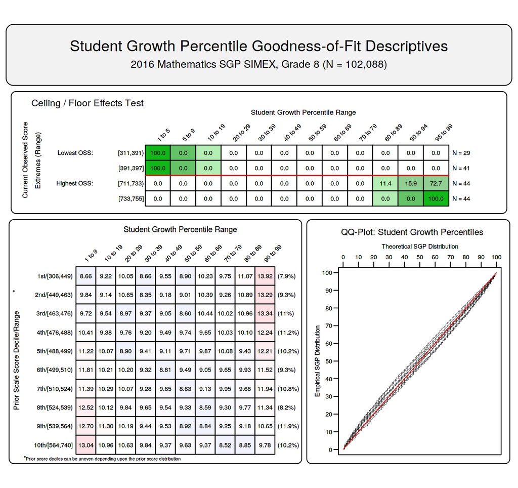

**Figure 4:** Goodness of Fit Plot for 2016 *Ranked SIMEX* 8<sup>th</sup> Grade Mathematics SGPs.

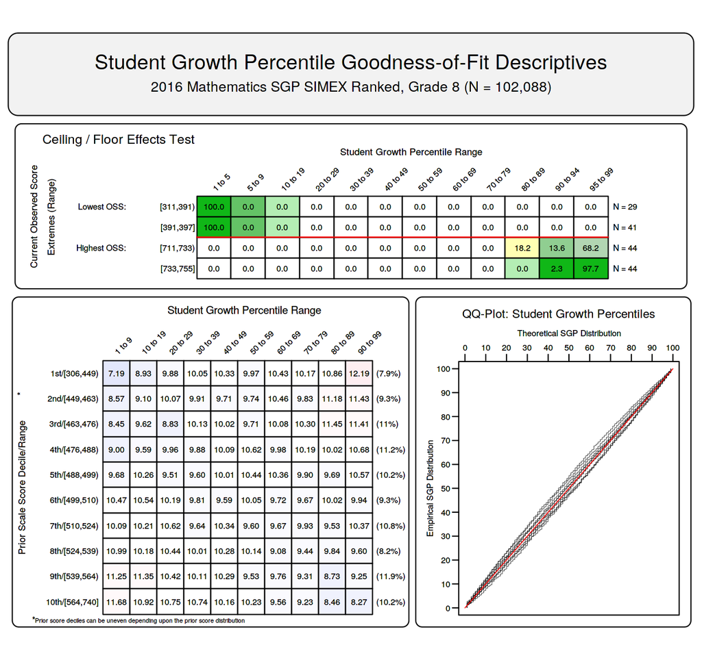

# 3 Relationship of Ranked SIMEX with Prior Student Achievement

## 3.1 EOG Subjects

| **Table 1:** Student Level Correlations between Prior Standardized Scale Score and 1) Current Scale Score, 2) Standard SGP, 3) SIMEX SGP and 4) Ranked SIMEX SGP. Content Area | **Table 1:** Student Level Correlations between Prior Standardized Scale Score and 1) Current Scale Score, 2) Standard SGP, 3) SIMEX SGP and 4) Ranked SIMEX SGP. Grade | **Table 1:** Student Level Correlations between Prior Standardized Scale Score and 1) Current Scale Score, 2) Standard SGP, 3) SIMEX SGP and 4) Ranked SIMEX SGP. | **Table 1:** Student Level Correlations between Prior Standardized Scale Score and 1) Current Scale Score, 2) Standard SGP, 3) SIMEX SGP and 4) Ranked SIMEX SGP. | **Table 1:** Student Level Correlations between Prior Standardized Scale Score and 1) Current Scale Score, 2) Standard SGP, 3) SIMEX SGP and 4) Ranked SIMEX SGP. | **Table 1:** Student Level Correlations between Prior Standardized Scale Score and 1) Current Scale Score, 2) Standard SGP, 3) SIMEX SGP and 4) Ranked SIMEX SGP. | **Table 1:** Student Level Correlations between Prior Standardized Scale Score and 1) Current Scale Score, 2) Standard SGP, 3) SIMEX SGP and 4) Ranked SIMEX SGP. N Size |
| --- | --- | --- | --- | --- | --- | --- |
| ELA | 4 | 0.83 | 0.00 | -0.12 | -0.12 | 123,767 |
|  | 5 | 0.83 | 0.01 | -0.07 | -0.07 | 122,053 |
|  | 6 | 0.84 | 0.01 | -0.07 | -0.07 | 119,853 |
|  | 7 | 0.84 | 0.02 | -0.07 | -0.07 | 118,962 |
|  | 8 | 0.83 | 0.02 | -0.07 | -0.07 | 120,474 |
| Mathematics | 4 | 0.84 | 0.00 | -0.10 | -0.10 | 124,313 |
|  | 5 | 0.84 | 0.01 | -0.07 | -0.07 | 122,680 |
|  | 6 | 0.84 | 0.01 | -0.06 | -0.06 | 120,376 |
|  | 7 | 0.87 | 0.02 | -0.07 | -0.07 | 118,986 |
|  | 8 | 0.81 | 0.02 | -0.06 | -0.06 | 102,088 |
| Science | 4 | 0.79 | 0.00 | -0.10 | -0.10 | 124,092 |
|  | 5 | 0.80 | 0.00 | -0.07 | -0.07 | 122,488 |
|  | 6 | 0.80 | 0.00 | -0.08 | -0.08 | 120,164 |
|  | 7 | 0.83 | 0.00 | -0.07 | -0.07 | 119,107 |
|  | 8 | 0.78 | 0.00 | -0.06 | -0.06 | 94,694 |
| Social Studies | 4 | 0.77 | 0.00 | -0.09 | -0.09 | 123,446 |
|  | 5 | 0.80 | 0.00 | -0.08 | -0.08 | 121,783 |
|  | 6 | 0.80 | 0.00 | -0.08 | -0.08 | 119,550 |
|  | 7 | 0.84 | 0.00 | -0.08 | -0.08 | 118,545 |
|  | 8 | 0.82 | 0.00 | -0.06 | -0.06 | 119,813 |

## 3.2 EOC Subjects

Each EOC test subject is analyzed using more than one sequence of prior subjects, grades and years, and these unique progressions are disaggregated in Tables 2 and 3 using the most recent prior available for each norm group (although more prior years’ scores are used in SGP calculations when available). These correlations between current and prior scale score are notably lower than in the grade level norm groups, and overall lower correlations may be expected in EOC subjects due to the change in specific subject from one course to the next.

As expected, the relationships between growth and prior achievement at the student level reported in Tables 2 and 3 are still non-existent for standard SGPs and slightly negative after SIMEX correction and SIMEX ranking. SIMEX and RS-SGP correlations are indistinguishable for EOCs as well.

| **Table 2:** EOC Student Level Correlations between Prior Standardized Score and 1) Current Scale Score, 2) Standard SGP, 3) SIMEX SGP and 4) Ranked SIMEX SGP - Disaggregated by Norm Group. Content Area | **Table 2:** EOC Student Level Correlations between Prior Standardized Score and 1) Current Scale Score, 2) Standard SGP, 3) SIMEX SGP and 4) Ranked SIMEX SGP - Disaggregated by Norm Group. Most Recent Prior | **Table 2:** EOC Student Level Correlations between Prior Standardized Score and 1) Current Scale Score, 2) Standard SGP, 3) SIMEX SGP and 4) Ranked SIMEX SGP - Disaggregated by Norm Group. | **Table 2:** EOC Student Level Correlations between Prior Standardized Score and 1) Current Scale Score, 2) Standard SGP, 3) SIMEX SGP and 4) Ranked SIMEX SGP - Disaggregated by Norm Group. | **Table 2:** EOC Student Level Correlations between Prior Standardized Score and 1) Current Scale Score, 2) Standard SGP, 3) SIMEX SGP and 4) Ranked SIMEX SGP - Disaggregated by Norm Group. | **Table 2:** EOC Student Level Correlations between Prior Standardized Score and 1) Current Scale Score, 2) Standard SGP, 3) SIMEX SGP and 4) Ranked SIMEX SGP - Disaggregated by Norm Group. | **Table 2:** EOC Student Level Correlations between Prior Standardized Score and 1) Current Scale Score, 2) Standard SGP, 3) SIMEX SGP and 4) Ranked SIMEX SGP - Disaggregated by Norm Group. N Size |
| --- | --- | --- | --- | --- | --- | --- |
| Grade 9 Lit | 2015 ELA Grade 7 | 0.75 | 0.02 | -0.10 | -0.10 | 4,075 |
|  | 2015 ELA Grade 8 | 0.82 | 0.02 | -0.07 | -0.07 | 115,378 |
|  | 2015 Grade 9 Lit | 0.63 | 0.00 | -0.09 | -0.09 | 5,279 |
| American Lit | 2013 Grade 9 Lit | 0.78 | 0.00 | -0.10 | -0.10 | 2,500 |
|  | 2014 Grade 9 Lit | 0.79 | 0.02 | -0.07 | -0.07 | 95,761 |
|  | 2015 American Lit | 0.65 | 0.00 | -0.09 | -0.09 | 4,596 |
|  | 2015 Grade 9 Lit | 0.77 | -0.01 | -0.10 | -0.10 | 8,176 |
| US History | 2012 Soc Studies Grade 8 | 0.66 | -0.01 | -0.07 | -0.07 | 1,909 |
|  | 2013 Soc Studies Grade 8 | 0.72 | 0.00 | -0.08 | -0.08 | 84,784 |
|  | 2014 Soc Studies Grade 8 | 0.74 | 0.00 | -0.09 | -0.09 | 10,283 |
|  | 2015 Economics | 0.76 | -0.01 | -0.10 | -0.10 | 4,389 |
|  | 2015 US History | 0.67 | 0.00 | -0.10 | -0.10 | 2,590 |
|  | 2016 Economics | 0.72 | 0.00 | -0.08 | -0.08 | 2,081 |
| Economics | 2012 Soc Studies Grade 8 | 0.73 | 0.00 | -0.08 | -0.08 | 3,309 |
|  | 2013 Soc Studies Grade 8 | 0.71 | 0.00 | -0.08 | -0.08 | 2,858 |
|  | 2014 Soc Studies Grade 8 | 0.73 | 0.00 | -0.11 | -0.11 | 3,146 |
|  | 2014 US History | 0.70 | 0.00 | -0.06 | -0.06 | 5,832 |
|  | 2015 Soc Studies Grade 8 | 0.74 | 0.00 | -0.11 | -0.11 | 2,225 |
|  | 2015 US History | 0.71 | 0.00 | -0.08 | -0.08 | 88,780 |
|  | 2016 Economics | 0.66 | -0.01 | -0.10 | -0.10 | 1,518 |

| **Table 3:** EOC Student Level Correlations between Prior Standardized Score and 1) Current Scale Score, 2) Standard SGP, 3) SIMEX SGP and 4) Ranked SIMEX SGP - by Norm Group (*Continued*). Content Area | **Table 3:** EOC Student Level Correlations between Prior Standardized Score and 1) Current Scale Score, 2) Standard SGP, 3) SIMEX SGP and 4) Ranked SIMEX SGP - by Norm Group (*Continued*). Most Recent Prior | **Table 3:** EOC Student Level Correlations between Prior Standardized Score and 1) Current Scale Score, 2) Standard SGP, 3) SIMEX SGP and 4) Ranked SIMEX SGP - by Norm Group (*Continued*). | **Table 3:** EOC Student Level Correlations between Prior Standardized Score and 1) Current Scale Score, 2) Standard SGP, 3) SIMEX SGP and 4) Ranked SIMEX SGP - by Norm Group (*Continued*). | **Table 3:** EOC Student Level Correlations between Prior Standardized Score and 1) Current Scale Score, 2) Standard SGP, 3) SIMEX SGP and 4) Ranked SIMEX SGP - by Norm Group (*Continued*). | **Table 3:** EOC Student Level Correlations between Prior Standardized Score and 1) Current Scale Score, 2) Standard SGP, 3) SIMEX SGP and 4) Ranked SIMEX SGP - by Norm Group (*Continued*). | **Table 3:** EOC Student Level Correlations between Prior Standardized Score and 1) Current Scale Score, 2) Standard SGP, 3) SIMEX SGP and 4) Ranked SIMEX SGP - by Norm Group (*Continued*). N Size |
| --- | --- | --- | --- | --- | --- | --- |
| Coordinate Algebra | 2015 Coord Algebra | 0.71 | 0.00 | -0.11 | -0.11 | 4,189 |
|  | 2015 Math Grd 7 | 0.73 | 0.01 | -0.10 | -0.10 | 3,148 |
|  | 2015 Math Grd 8 | 0.78 | 0.01 | -0.07 | -0.07 | 19,544 |
| Analytic Geometry | 2014 Coord Algebra | 0.57 | 0.00 | -0.08 | -0.08 | 1,831 |
|  | 2015 Analytic Geom | 0.58 | 0.00 | -0.10 | -0.10 | 6,792 |
|  | 2015 Coord Algebra | 0.75 | 0.02 | -0.07 | -0.07 | 84,634 |
| Algebra I | 2015 Math Grd 7 | 0.76 | 0.00 | -0.10 | -0.10 | 15,646 |
|  | 2015 Math Grd 8 | 0.80 | 0.02 | -0.06 | -0.06 | 75,621 |
| Geometry | 2015 Coord Algebra | 0.75 | 0.02 | -0.07 | -0.07 | 33,006 |
| Physical Science | 2014 Biology | 0.71 | 0.02 | -0.05 | -0.05 | 4,951 |
|  | 2014 Science Grd 8 | 0.69 | -0.01 | -0.07 | -0.07 | 3,236 |
|  | 2015 Biology | 0.73 | -0.01 | -0.08 | -0.08 | 36,140 |
|  | 2015 Physical Science | 0.58 | 0.00 | -0.11 | -0.11 | 2,944 |
|  | 2015 Science Grd 7 | 0.73 | 0.00 | -0.07 | -0.07 | 26,138 |
|  | 2015 Science Grd 8 | 0.78 | 0.00 | -0.08 | -0.08 | 18,411 |
| Biology | 2014 Physical Science | 0.84 | 0.00 | -0.09 | -0.09 | 2,753 |
|  | 2014 Science Grd 8 | 0.74 | -0.01 | -0.07 | -0.07 | 12,554 |
|  | 2015 Biology | 0.67 | 0.00 | -0.10 | -0.10 | 5,015 |
|  | 2015 Physical Science | 0.69 | 0.01 | -0.09 | -0.09 | 39,489 |
|  | 2015 Science Grd 8 | 0.77 | -0.03 | -0.10 | -0.10 | 60,608 |

## 3.3 Schools

We must also consider the impact the SIMEX ranking has on aggregated SGPs since they are used for school and teacher accountability in Georgia. The following tables looks at the correlations between school level aggregations (averages) of prior student achievement and growth from analyses for Georgia. Three years of results are provided.

| **Table 4:** 2014 to 2016 School Level EOG Correlations between Mean Prior Standardized Scale Score and Aggregate SGPs by Content Area. Content Area | **Table 4:** 2014 to 2016 School Level EOG Correlations between Mean Prior Standardized Scale Score and Aggregate SGPs by Content Area. Year | **Table 4:** 2014 to 2016 School Level EOG Correlations between Mean Prior Standardized Scale Score and Aggregate SGPs by Content Area. R Mean SGP | **Table 4:** 2014 to 2016 School Level EOG Correlations between Mean Prior Standardized Scale Score and Aggregate SGPs by Content Area. R Mean SIMEX | **Table 4:** 2014 to 2016 School Level EOG Correlations between Mean Prior Standardized Scale Score and Aggregate SGPs by Content Area. R Mean Ranked SIMEX | **Table 4:** 2014 to 2016 School Level EOG Correlations between Mean Prior Standardized Scale Score and Aggregate SGPs by Content Area. N |
| --- | --- | --- | --- | --- | --- |
| ELA | 2014 | 0.55 | 0.35 | 0.35 | 1,734 |
|  | 2015 | 0.42 | 0.26 | 0.26 | 1,743 |
|  | 2016 | 0.58 | 0.43 | 0.43 | 1,746 |
| Mathematics | 2014 | 0.45 | 0.32 | 0.32 | 1,734 |
|  | 2015 | 0.46 | 0.36 | 0.36 | 1,743 |
|  | 2016 | 0.51 | 0.41 | 0.41 | 1,746 |
| Science | 2014 | 0.41 | 0.25 | 0.25 | 1,737 |
|  | 2015 | 0.40 | 0.28 | 0.28 | 1,746 |
|  | 2016 | 0.50 | 0.39 | 0.39 | 1,745 |
| Social Studies | 2014 | 0.35 | 0.20 | 0.20 | 1,737 |
|  | 2015 | 0.34 | 0.20 | 0.20 | 1,746 |
|  | 2016 | 0.44 | 0.33 | 0.33 | 1,746 |

| **Table 5:** 2014 to 2016 School Level EOC Correlations between Mean Prior Standardized Scale Score and Aggregate SGPs by Content Area. Content Area | **Table 5:** 2014 to 2016 School Level EOC Correlations between Mean Prior Standardized Scale Score and Aggregate SGPs by Content Area. Year | **Table 5:** 2014 to 2016 School Level EOC Correlations between Mean Prior Standardized Scale Score and Aggregate SGPs by Content Area. R Mean SGP | **Table 5:** 2014 to 2016 School Level EOC Correlations between Mean Prior Standardized Scale Score and Aggregate SGPs by Content Area. R Mean SIMEX | **Table 5:** 2014 to 2016 School Level EOC Correlations between Mean Prior Standardized Scale Score and Aggregate SGPs by Content Area. R Mean Ranked SIMEX | **Table 5:** 2014 to 2016 School Level EOC Correlations between Mean Prior Standardized Scale Score and Aggregate SGPs by Content Area. N |
| --- | --- | --- | --- | --- | --- |
| Grade 9 Lit | 2014 | 0.44 | 0.21 | 0.21 | 468 |
|  | 2015 | 0.33 | 0.21 | 0.21 | 485 |
|  | 2016 | 0.55 | 0.43 | 0.43 | 493 |
| American Lit | 2014 | 0.49 | 0.26 | 0.26 | 425 |
|  | 2015 | 0.31 | 0.18 | 0.18 | 425 |
|  | 2016 | 0.60 | 0.51 | 0.51 | 433 |
| US History | 2014 | 0.11 | 0.01 | 0.01 | 421 |
|  | 2015 | 0.14 | 0.05 | 0.05 | 422 |
|  | 2016 | 0.27 | 0.18 | 0.18 | 428 |
| Economics | 2014 | 0.15 | 0.06 | 0.06 | 416 |
|  | 2015 | 0.12 | 0.04 | 0.04 | 424 |
|  | 2016 | 0.38 | 0.29 | 0.29 | 425 |
| Coordinate Algebra | 2014 | 0.40 | 0.24 | 0.24 | 639 |
|  | 2015 | 0.36 | 0.22 | 0.22 | 711 |
|  | 2016 | 0.33 | 0.22 | 0.22 | 206 |
| Analytic Geometry | 2014 | 0.48 | 0.32 | 0.32 | 421 |
|  | 2015 | 0.45 | 0.33 | 0.33 | 431 |
|  | 2016 | 0.53 | 0.42 | 0.42 | 332 |
| Algebra I | 2016 | 0.35 | 0.24 | 0.24 | 560 |
| Geometry | 2016 | 0.59 | 0.48 | 0.48 | 122 |
| Physical Science | 2014 | 0.30 | 0.19 | 0.19 | 457 |
|  | 2015 | 0.33 | 0.24 | 0.24 | 529 |
|  | 2016 | 0.34 | 0.27 | 0.27 | 574 |
| Biology | 2014 | 0.21 | 0.08 | 0.08 | 426 |
|  | 2015 | 0.30 | 0.20 | 0.20 | 436 |
|  | 2016 | 0.33 | 0.23 | 0.23 | 438 |

# 4 Differences between SIMEX and Ranked SIMEX SGPs

Given that the correlations between prior achievement and growth are essentially identical for SIMEX and RS-SGPs, and yet there are visible differences in their distributions and model fit charts, we now investigate the absolute differences between the two values at the student and school levels.

## 4.1 SGP Change at Individual Student Level

When replacing SIMEX with ranked SIMEX, students with higher SIMEX SGP tend to receive lower ranked SIMEX SGP, students with lower SIMEX SGP tend to receive higher ranked SIMEX SGP. The correlation between SGP difference and SIMEX SGP is -0.82. Most of the students have SGP change within 2 percentiles.

| **Table 6:** The Change of SGP (Ranked SIMEX - SIMEX) by EOG Subject and MeanGP SIMEX. Subject | **Table 6:** The Change of SGP (Ranked SIMEX - SIMEX) by EOG Subject and MeanGP SIMEX. SGP Difference | **Table 6:** The Change of SGP (Ranked SIMEX - SIMEX) by EOG Subject and MeanGP SIMEX. Mean SIMEX SGP | **Table 6:** The Change of SGP (Ranked SIMEX - SIMEX) by EOG Subject and MeanGP SIMEX. N |
| --- | --- | --- | --- |
| ELA | -3 | 84.56 | 4,903 |
|  | -2 | 82.53 | 115,599 |
|  | -1 | 74.94 | 129,685 |
|  | 0 | 50.71 | 93,362 |
|  | 1 | 25.93 | 124,764 |
|  | 2 | 18.52 | 125,827 |
|  | 3 | 15.09 | 10,969 |
| Mathematics | -4 | 85.00 | 19 |
|  | -3 | 82.50 | 8,834 |
|  | -2 | 81.21 | 116,896 |
|  | -1 | 73.41 | 132,958 |
|  | 0 | 46.01 | 103,661 |
|  | 1 | 22.51 | 152,706 |
|  | 2 | 16.93 | 72,888 |
|  | 3 | 19.45 | 481 |
| Science | -3 | 82.27 | 974 |
|  | -2 | 81.08 | 87,952 |
|  | -1 | 75.75 | 153,206 |
|  | 0 | 47.13 | 117,345 |
|  | 1 | 22.71 | 160,754 |
|  | 2 | 17.95 | 59,845 |
|  | 3 | 17.57 | 469 |
| Social Studies | -3 | 78.44 | 590 |
|  | -2 | 80.80 | 95,647 |
|  | -1 | 75.55 | 160,955 |
|  | 0 | 46.18 | 125,384 |
|  | 1 | 21.93 | 167,644 |
|  | 2 | 16.95 | 52,626 |
|  | 3 | 17.57 | 291 |

| **Table 7:** The Change of SGP (Ranked SIMEX - SIMEX) by EOC Subject and MeanGP SIMEX. Subject | **Table 7:** The Change of SGP (Ranked SIMEX - SIMEX) by EOC Subject and MeanGP SIMEX. SGP Difference | **Table 7:** The Change of SGP (Ranked SIMEX - SIMEX) by EOC Subject and MeanGP SIMEX. Mean SIMEX SGP | **Table 7:** The Change of SGP (Ranked SIMEX - SIMEX) by EOC Subject and MeanGP SIMEX. N |
| --- | --- | --- | --- |
| Grade 9 Lit | -3 | 84.19 | 1,229 |
|  | -2 | 83.39 | 24,230 |
|  | -1 | 75.51 | 23,621 |
|  | 0 | 51.63 | 21,654 |
|  | 1 | 25.16 | 26,820 |
|  | 2 | 18.56 | 26,322 |
|  | 3 | 16.40 | 856 |
| American Lit | -5 | 95.00 | 6 |
|  | -4 | 90.36 | 184 |
|  | -3 | 84.93 | 3,206 |
|  | -2 | 82.28 | 26,494 |
|  | -1 | 70.17 | 19,128 |
|  | 0 | 47.46 | 17,546 |
|  | 1 | 23.81 | 27,111 |
|  | 2 | 16.51 | 16,456 |
|  | 3 | 14.97 | 891 |
|  | 4 | 15.00 | 11 |
| US History | -3 | 79.48 | 42 |
|  | -2 | 81.69 | 8,304 |
|  | -1 | 76.15 | 34,751 |
|  | 0 | 43.85 | 29,461 |
|  | 1 | 21.07 | 30,119 |
|  | 2 | 19.75 | 3,351 |
|  | 3 | 34.00 | 8 |
| Economics | -4 | 70.44 | 16 |
|  | -3 | 76.48 | 182 |
|  | -2 | 79.48 | 4,256 |
|  | -1 | 75.06 | 39,196 |
|  | 0 | 43.38 | 34,855 |
|  | 1 | 20.38 | 28,252 |
|  | 2 | 19.81 | 911 |

| **Table 8:** The Change of SGP (Ranked SIMEX - SIMEX) by EOC Subject and MeanGP SIMEX (Continued). Subject | **Table 8:** The Change of SGP (Ranked SIMEX - SIMEX) by EOC Subject and MeanGP SIMEX (Continued). SGP Difference | **Table 8:** The Change of SGP (Ranked SIMEX - SIMEX) by EOC Subject and MeanGP SIMEX (Continued). Mean SIMEX SGP | **Table 8:** The Change of SGP (Ranked SIMEX - SIMEX) by EOC Subject and MeanGP SIMEX (Continued). N |
| --- | --- | --- | --- |
| Coordinate Algebra | -3 | 88.11 | 132 |
|  | -2 | 82.42 | 3,935 |
|  | -1 | 77.28 | 6,543 |
|  | 0 | 47.85 | 5,603 |
|  | 1 | 22.82 | 7,710 |
|  | 2 | 17.66 | 2,913 |
|  | 3 | 20.76 | 45 |
| Analytic Geometry | -3 | 82.38 | 945 |
|  | -2 | 82.56 | 13,398 |
|  | -1 | 76.40 | 22,639 |
|  | 0 | 46.66 | 21,341 |
|  | 1 | 22.32 | 26,164 |
|  | 2 | 17.29 | 8,645 |
|  | 3 | 16.11 | 125 |
| Algebra I | -4 | 79.00 | 4 |
|  | -3 | 84.74 | 310 |
|  | -2 | 83.60 | 13,400 |
|  | -1 | 75.83 | 23,323 |
|  | 0 | 46.04 | 19,656 |
|  | 1 | 22.45 | 25,781 |
|  | 2 | 18.07 | 8,790 |
|  | 3 | 21.33 | 3 |
| Geometry | -4 | 87.79 | 24 |
|  | -3 | 84.23 | 1,120 |
|  | -2 | 80.91 | 5,696 |
|  | -1 | 74.26 | 7,190 |
|  | 0 | 50.15 | 5,323 |
|  | 1 | 22.73 | 8,659 |
|  | 2 | 17.73 | 4,436 |
|  | 3 | 13.80 | 558 |

| **Table 9:** The Change of SGP (Ranked SIMEX - SIMEX) by EOC Subject and MeanGP SIMEX (Continued). Subject | **Table 9:** The Change of SGP (Ranked SIMEX - SIMEX) by EOC Subject and MeanGP SIMEX (Continued). SGP Difference | **Table 9:** The Change of SGP (Ranked SIMEX - SIMEX) by EOC Subject and MeanGP SIMEX (Continued). Mean SIMEX SGP | **Table 9:** The Change of SGP (Ranked SIMEX - SIMEX) by EOC Subject and MeanGP SIMEX (Continued). N |
| --- | --- | --- | --- |
| Physical Science | -3 | 82.81 | 16 |
|  | -2 | 82.45 | 5,699 |
|  | -1 | 76.95 | 29,913 |
|  | 0 | 45.79 | 24,084 |
|  | 1 | 21.80 | 30,114 |
|  | 2 | 19.10 | 1,991 |
|  | 3 | 19.00 | 3 |
| Biology | -3 | 85.43 | 606 |
|  | -2 | 80.74 | 22,085 |
|  | -1 | 75.25 | 26,934 |
|  | 0 | 48.13 | 21,032 |
|  | 1 | 23.12 | 29,226 |
|  | 2 | 18.53 | 20,181 |
|  | 3 | 16.25 | 355 |

## 4.2 Mean SGP Change at School Level

Most of the schools have mean student growth percentile (MSGP) change within 2 percentiles when switching from SIMEX to Ranked SIMEX.

| **Table 10:** Descriptive statistics of school MGP change to ranked SIMEX SGP (Ranked - SIMEX). Subject | **Table 10:** Descriptive statistics of school MGP change to ranked SIMEX SGP (Ranked - SIMEX). Min. | **Table 10:** Descriptive statistics of school MGP change to ranked SIMEX SGP (Ranked - SIMEX). 1st Qu. | **Table 10:** Descriptive statistics of school MGP change to ranked SIMEX SGP (Ranked - SIMEX). Median | **Table 10:** Descriptive statistics of school MGP change to ranked SIMEX SGP (Ranked - SIMEX). Mean | **Table 10:** Descriptive statistics of school MGP change to ranked SIMEX SGP (Ranked - SIMEX). 3rd Qu. | **Table 10:** Descriptive statistics of school MGP change to ranked SIMEX SGP (Ranked - SIMEX). Max. | **Table 10:** Descriptive statistics of school MGP change to ranked SIMEX SGP (Ranked - SIMEX). SD | **Table 10:** Descriptive statistics of school MGP change to ranked SIMEX SGP (Ranked - SIMEX). N |
| --- | --- | --- | --- | --- | --- | --- | --- | --- |
| ELA | -0.67 | -0.09 | 0.06 | 0.07 | 0.22 | 1.56 | 0.24 | 1,746 |
| Mathematics | -1.29 | -0.36 | -0.16 | -0.14 | 0.07 | 1.17 | 0.31 | 1,746 |
| Science | -1.06 | -0.21 | -0.06 | -0.05 | 0.11 | 0.81 | 0.24 | 1,745 |
| Social Studies | -1.03 | -0.29 | -0.11 | -0.11 | 0.06 | 0.97 | 0.27 | 1,746 |
| Grade 9 Lit | -1.16 | -0.14 | 0.05 | 0.04 | 0.24 | 1.06 | 0.32 | 493 |
| American Lit | -1.06 | -0.34 | -0.13 | -0.10 | 0.13 | 1.31 | 0.35 | 433 |
| US History | -0.72 | -0.27 | -0.09 | -0.08 | 0.12 | 0.93 | 0.29 | 428 |
| Economics | -0.80 | -0.31 | -0.14 | -0.13 | 0.01 | 0.60 | 0.23 | 425 |
| Coordinate Algebra | -1.39 | -0.39 | -0.03 | -0.08 | 0.26 | 0.82 | 0.48 | 206 |
| Analytic Geometry | -0.97 | -0.25 | -0.04 | -0.05 | 0.15 | 0.71 | 0.30 | 332 |
| Algebra I | -1.41 | -0.44 | -0.13 | -0.14 | 0.19 | 0.90 | 0.45 | 560 |
| Geometry | -1.04 | -0.27 | 0.07 | 0.00 | 0.26 | 0.89 | 0.38 | 122 |
| Physical Science | -1.10 | -0.28 | -0.06 | -0.08 | 0.15 | 0.67 | 0.33 | 574 |
| Biology | -0.93 | -0.24 | 0.01 | 0.00 | 0.20 | 1.06 | 0.35 | 438 |

**Figure 5:** School MGP change (MGP Ranked SIMEX - MGP SIMEX) by EOG Subjects.

[figure not shown]

**Figure 6:** School MGP change (MGP Ranked SIMEX - MGP SIMEX) by EOC Subjects.

[figure not shown]

**Figure 7:** School MGP change (MGP Ranked SIMEX - MGP SIMEX) by EOC Subjects (Continued).

[figure not shown]

**Figure 8:** School MGP change (MGP Ranked SIMEX - MGP SIMEX) by EOC Subjects (Continued).

[figure not shown]

# References

Betebenner, D. W., VanIwaarden, A., Domingue, B., & Shang, Y. (2017). *SGP: Student growth percentiles & percentile growth trajectories.* Retrieved from sgp.io

Castellano, K. E., & McCaffrey, D. F. (2017). The accuracy of aggregate student growth percentiles as indicators of educator performance. *Educational Measurement: Issues and Practice*, *36*(1), 14–27. Retrieved from http://dx.doi.org/10.1111/emip.12144

Lockwood, J. R., & Castellano, K. E. (2015). Alternative statistical frameworks for student growth percentile estimation. *Statistics and Public Policy*, *2*(1), 1–9. Retrieved from http://dx.doi.org/10.1080/2330443X.2014.962718

McCaffrey, D. F., Castellano, K. E., & Lockwood, J. R. (2015). The impact of measurement error on the accuracy of individual and aggregate sgp. *Educational Measurement: Issues and Practice*, *34*(1), 15–21. Retrieved from http://dx.doi.org/10.1111/emip.12062

Shang, Y., VanIwaarden, A., & Betebenner, D. W. (2015). Covariate measurement error correction for student growth percentiles using the simex method. *Educational Measurement: Issues and Practice*, *34*(1), 4–14. Retrieved from http://dx.doi.org/10.1111/emip.12058

[^1]: SGP versions 1.7-0.0 and later
[^2]: Calculated as (rank(SIMEX SGP)/N) x 100 where N is the number of students. The result is rounded to the nearest integer.
[^3]: SGP estimates are found by predicting 100 scores for each student - one for each percentile. The position (1-99) of the predicted score that is closest to a student’s observed score is their estimated SGP.